# MP_SRF_miTags_18S_and_16S_diversity_analysis

lrubinat

03/05/2016

# 1) 18S amplicons

## 1.1) Data overview

Let’s read the dataset and remove the samples containing less than 470 reads:

```
## [1] 1641   13
```

```
##     OTUId st019 st030 st044 st063
## 1 OTU_314    17     3    14    14
## 2 OTU_893     7     2     2     4
## 3 OTU_896     7     2     2     7
## 4 OTU_901     1     0     4     0
## 5 OTU_902    10     1     5     1
```

```
## [1] 1641   12
```

```
##         st019 st030 st044 st063 st076
## OTU_314    17     3    14    14    28
## OTU_893     7     2     2     4     7
## OTU_896     7     2     2     7     3
## OTU_901     1     0     4     0    17
## OTU_902    10     1     5     1     8
```

```
## [1] 1641    2
```

```
##                                                                                                                                         taxonomic_classification
## OTU_314 5396_AB199888|Eukaryota|Hacrobia|Haptophyta|Prymnesiophyceae|Prymnesiophyceae_X|Phaeocystales|Phaeocystales_X|Phaeocystaceae|Phaeocystis|Phaeocystis_sp.
## OTU_893                                               GU821879.1.1200_Eukaryota;SAR;Alveolata;Protalveolata;Syndiniales;Syndiniales_Group_II;uncultured_Rhizaria
## OTU_896                                        DQ103794.1.1636_Eukaryota;SAR;Alveolata;Protalveolata;Syndiniales;Syndiniales_Group_I;uncultured_marine_eukaryote
## OTU_901                                  EF455763.1.1872_Eukaryota;SAR;Stramenopiles;Ochrophyta;Pelagophyceae;Pelagomonadales;Pelagomonas;Pelagomonas_calceolata
## OTU_902                                              GU824951.1.1201_Eukaryota;SAR;Alveolata;Protalveolata;Syndiniales;Syndiniales_Group_II;uncultured_eukaryote
##                         class
## OTU_314      Prymnesiophyceae
## OTU_893 heterotrophic_protist
## OTU_896 heterotrophic_protist
## OTU_901         Pelagophyceae
## OTU_902 heterotrophic_protist
```

```
## [1] 1641   10
```

```
##         st019 st030 st044 st063 st076
## OTU_314    17     3    14    14    28
## OTU_893     7     2     2     4     7
## OTU_896     7     2     2     7     3
## OTU_901     1     0     4     0    17
## OTU_902    10     1     5     1     8
```

```
## st030
##   133
```

```
## [1] 1641    9
```

## 1.2) Normalization

Let’s normalize the original dataset by randomly subsampling 470 reads in each station:

```r
library(vegan)
MP_18S_miTags_tax_occur_min470_t<-t(MP_18S_miTags_tax_occur_min470)
MP_18S_miTags_tax_occur_ss470<-rrarefy(MP_18S_miTags_tax_occur_min470_t, 470)
```

The normalized table shows the following dimensions and format:

```
## [1]    9 1641
```

```
##       OTU_314 OTU_893 OTU_896 OTU_901 OTU_902
## st019      10       2       4       0       4
## st044       8       2       1       4       4
## st063      12       2       4       0       1
## st076      16       4       2       6       5
## st083       8       6       0       0       4
```

Its content fits with the expected normalization values (470 reads per station):

```r
rowSums(MP_18S_miTags_tax_occur_ss470)
```

```
## st019 st044 st063 st076 st083 st092 st101 st120 st141
##   470   470   470   470   470   470   470   470   470
```

Let’s check out how many OTUs don’t appear in the new table:

```r
length(which(colSums(MP_18S_miTags_tax_occur_ss470)==0))
```

```
## [1] 413
```

```r
MP_18S_miTags_tax_occur_ss470_no_cero<-MP_18S_miTags_tax_occur_ss470[,-(which(colSums(MP_18S_miTags_tax_occur_ss470)==0))]
dim(MP_18S_miTags_tax_occur_ss470_no_cero)
```

```
## [1]    9 1228
```

## 1.3) Taxonomic composition analysis

Let’s add the taxonomic classification to the left OTUs by merging “MP_18S_miTags_tax_occur_ss470_no_cero” with “MP_18S_tax”:

```
## [1] 1228   12
```

```
##   Row.names st019 st044 st063 st076
## 1 OTU_10103     0     0     0     0
## 2 OTU_10105     0     0     0     0
## 3 OTU_10107     0     0     0     0
## 4 OTU_10116     0     0     0     0
## 5 OTU_10118     0     0     0     0
```

```
## [1] 1228   11
```

```
##           st019 st044 st063 st076 st083
## OTU_10103     0     0     0     0     0
## OTU_10105     0     0     0     0     0
## OTU_10107     0     0     0     0     0
## OTU_10116     0     0     0     0     0
## OTU_10118     0     0     0     0     0
```

```
## [1] 1228   12
```

```
##         st019 st044 st063 st076 st083
## OTU_314    10     8    12    16     8
## OTU_893     2     2     2     4     6
## OTU_896     4     1     4     2     0
## OTU_901     0     4     0     6     0
## OTU_902     4     4     1     5     4
```

```
## [1] 389  12
```

```
##          st019 st044 st063 st076 st083
## OTU_1291     4     0     2     0     3
## OTU_1292     2     0     5     0     4
## OTU_1427     0     1     2     1     2
## OTU_1435     2     3     2     0     4
## OTU_1697     2     1     1     1     1
```

```
##          st019 st044 st063 st076 st083
## OTU_1291     4     0     2     0     3
## OTU_1292     2     0     5     0     4
## OTU_1427     0     1     2     1     2
## OTU_1435     2     3     2     0     4
## OTU_1697     2     1     1     1     1
```

```
## [1] 135   9
```

```
## [1] 9
```

```
## [1] 7
```

```
## [1] 9
```

```
## [1] 7
```

```
## [1] 9
```

```
## [1] 9
```

```
## [1] 8
```

```
## [1] 6
```

```
## [1] 4
```

```
## [1] 0
```

```
## [1] 9
```

```
## [1] 2
```

```
## [1] 2
```

```
## [1] 0
```

```
## [1] 0
```

```
## [1] 0
```

```
## [1] 0
```

```
## [1] 0
```

```
## [1] 0
```

```
## [1] 1
```

```
## [1] 0
```

```
## [1] 1
```

```
## [1] 8
```

```
## [1] 1
```

```
##                Group.1   x
## 14    Prymnesiophyceae 608
## 8          Dinophyceae 360
## 12       Pelagophyceae 121
## 5        Chrysophyceae 111
## 7     Dictyochophyceae  63
## 6      Cryptomonadales  32
## 13      Prasinophyceae  30
## 1      Bacillariophyta  23
## 3   Chlorarachniophyta  10
## 11      Pavlovophyceae   9
## 2        Bolidophyceae   5
## 9        Eustigmatales   3
## 10     Mamiellophyceae   3
## 4  Chlorodendrophyceae   1
## 15          Rappemonad   1
## 16          Rhodophyta   1
```

```
##                Group.1   x
## 8          Dinophyceae 135
## 14    Prymnesiophyceae  97
## 5        Chrysophyceae  51
## 6      Cryptomonadales  21
## 7     Dictyochophyceae  21
## 12       Pelagophyceae  16
## 1      Bacillariophyta  14
## 13      Prasinophyceae   9
## 3   Chlorarachniophyta   7
## 11      Pavlovophyceae   6
## 2        Bolidophyceae   5
## 9        Eustigmatales   2
## 10     Mamiellophyceae   2
## 4  Chlorodendrophyceae   1
## 15          Rappemonad   1
## 16          Rhodophyta   1
```

```
##                     reads_per_class OTUs_per_class
## Bacillariophyta                  23             14
## Bolidophyceae                     5              5
## Chlorarachniophyta               10              7
## Chlorodendrophyceae               1              1
## Chrysophyceae                   111             51
## Cryptomonadales                  32             21
## Dictyochophyceae                 63             21
## Dinophyceae                     360            135
## Eustigmatales                     3              2
## Mamiellophyceae                   3              2
## Pavlovophyceae                    9              6
## Pelagophyceae                   121             16
## Prasinophyceae                   30              9
## Prymnesiophyceae                608             97
## Rappemonad                        1              1
## Rhodophyta                        1              1
```

```
##                     reads_per_class OTUs_per_class samples_per_class
## Prymnesiophyceae                608             97                 9
## Dinophyceae                     360            135                 9
## Pelagophyceae                   121             16                 7
## Chrysophyceae                   111             51                 9
## Dictyochophyceae                 63             21                 9
## Cryptomonadales                  32             21                 9
## Prasinophyceae                   30              9                 7
## Bacillariophyta                  23             14                 8
## Chlorarachniophyta               10              7                 6
## Pavlovophyceae                    9              6                 8
## Bolidophyceae                     5              5                 4
## Eustigmatales                     3              2                 2
## Mamiellophyceae                   3              2                 2
## Chlorodendrophyceae               1              1                 1
## Rappemonad                        1              1                 1
## Rhodophyta                        1              1                 1
```

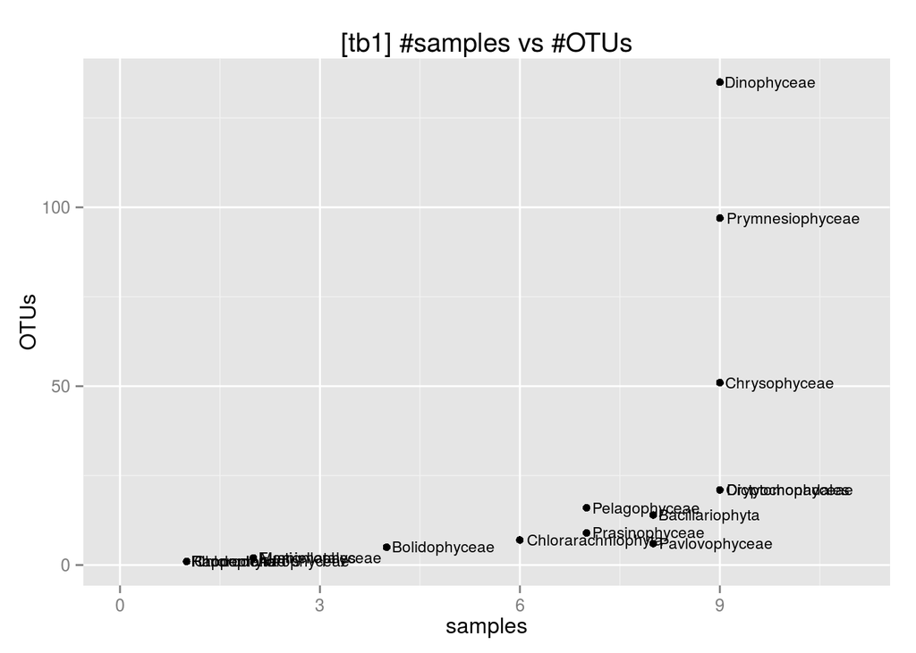

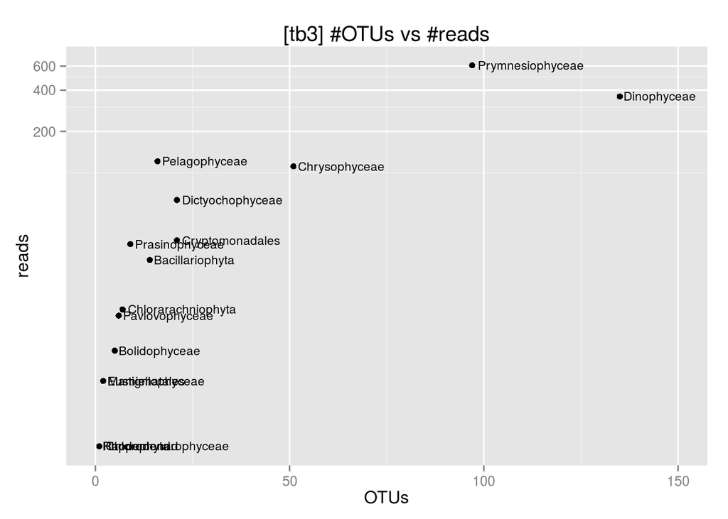

# 2) 16S amplicons

## 2.1) Data overview

```
## [1] 8248   14
```

```
##   OTUId st019 st030 st044 st063
## 1 OTU_1  1510   436   344   504
## 2 OTU_2   952   232   529   349
## 3 OTU_3   520   668   490   421
## 4 OTU_4   717   132   341   244
## 5 OTU_5   631   124   360   242
```

```
## [1] 8248   13
```

```
##       st019 st030 st044 st063 st076
## OTU_1  1510   436   344   504    88
## OTU_2   952   232   529   349   168
## OTU_3   520   668   490   421    93
## OTU_4   717   132   341   244   104
## OTU_5   631   124   360   242   106
```

```
## [1] 8248    3
```

```
##                                                                                                           taxonomic_classification
## OTU_1                GU940899.1.1230_Bacteria;Cyanobacteria;Cyanobacteria;SubsectionI;FamilyI;Prochlorococcus;uncultured_bacterium
## OTU_2                EU802538.1.1286_Bacteria;Proteobacteria;Deltaproteobacteria;SAR324_clade(Marine_group_B);uncultured_bacterium
## OTU_3                       EU802992.1.1202_Bacteria;Proteobacteria;Alphaproteobacteria;SAR11_clade;Surface_1;uncultured_bacterium
## OTU_4                EU802790.1.1266_Bacteria;Cyanobacteria;Cyanobacteria;SubsectionI;FamilyI;Prochlorococcus;uncultured_bacterium
## OTU_5 AY664211.1.1287|Bacteria|Cyanobacteria|Cyanobacteria|SubsectionI|FamilyI|Synechococcus|uncultured|uncultured+Prochlorococcus
##                      class_A                class_B
## OTU_1          cyanobacteria        Prochlorococcus
## OTU_2 heterotrophic_bacteria heterotrophic_bacteria
## OTU_3 heterotrophic_bacteria heterotrophic_bacteria
## OTU_4          cyanobacteria        Prochlorococcus
## OTU_5          cyanobacteria        Prochlorococcus
```

```
## [1] 8248   10
```

```
##       st019 st030 st044 st063 st076
## OTU_1  1510   436   344   504    88
## OTU_2   952   232   529   349   168
## OTU_3   520   668   490   421    93
## OTU_4   717   132   341   244   104
## OTU_5   631   124   360   242   106
```

```
## st101 st120
## 13676 17781
```

```
## [1] 8248    9
```

```
##       st019 st044 st063 st076 st083
## OTU_1  1510   344   504    88  1783
## OTU_2   952   529   349   168  1105
## OTU_3   520   490   421    93   517
## OTU_4   717   341   244   104   922
## OTU_5   631   360   242   106   715
```

## 2.2) Normalization

Let’s normalize the original dataset by randomly subsampling 13676 reads in each station:

```r
MP_16S_miTags_tax_occur_min13676_t<-t(MP_16S_miTags_tax_occur_min13676)
MP_16S_miTags_tax_occur_ss13676<-rrarefy(MP_16S_miTags_tax_occur_min13676_t, 13676)
```

The normalized table shows the following dimensions and format:

```
## [1]    9 8248
```

```
##       OTU_1 OTU_2 OTU_3 OTU_4 OTU_5
## st019   530   357   184   256   215
## st044   111   198   174   129   130
## st063   312   211   278   160   144
## st076    48    81    45    54    53
## st083   649   398   182   352   281
```

Its content fits with the expected normalization values (13676 reads per station):

```r
rowSums(MP_16S_miTags_tax_occur_ss13676)
```

```
## st019 st044 st063 st076 st083 st092 st101 st120 st141
## 13676 13676 13676 13676 13676 13676 13676 13676 13676
```

Let’s check out how many OTUs don’t appear in the new table:

```r
length(which(colSums(MP_16S_miTags_tax_occur_ss13676)==0))
```

```
## [1] 2199
```

```r
MP_16S_miTags_tax_occur_ss13676_no_cero<-MP_16S_miTags_tax_occur_ss13676[,-(which(colSums(MP_16S_miTags_tax_occur_ss13676)==0))]
dim(MP_16S_miTags_tax_occur_ss13676_no_cero)
```

```
## [1]    9 6049
```

## 2.3) Taxonomic composition analysis

Let’s add the taxonomic classification to the left OTUs by merging “MP_16S_miTags_tax_occur_ss13676_no_cero” with “MP_16S_miTags_tax”.

```
## [1] 6049   13
```

```
##   Row.names st019 st044 st063 st076
## 1     OTU_1   530   111   312    48
## 2    OTU_10    65   158   115   217
## 3   OTU_100    27    26    36     8
## 4  OTU_1000     0     4     2     2
## 5 OTU_10002     0     0     0     0
```

```
## [1] 6049   12
```

```
##           st019 st044 st063 st076 st083
## OTU_1       530   111   312    48   649
## OTU_10       65   158   115   217    54
## OTU_100      27    26    36     8    43
## OTU_1000      0     4     2     2     2
## OTU_10002     0     0     0     0     0
```

```
## [1] 6049   13
```

```
##                                                                                                           taxonomic_classification
## OTU_1                GU940899.1.1230_Bacteria;Cyanobacteria;Cyanobacteria;SubsectionI;FamilyI;Prochlorococcus;uncultured_bacterium
## OTU_2                EU802538.1.1286_Bacteria;Proteobacteria;Deltaproteobacteria;SAR324_clade(Marine_group_B);uncultured_bacterium
## OTU_3                       EU802992.1.1202_Bacteria;Proteobacteria;Alphaproteobacteria;SAR11_clade;Surface_1;uncultured_bacterium
## OTU_4                EU802790.1.1266_Bacteria;Cyanobacteria;Cyanobacteria;SubsectionI;FamilyI;Prochlorococcus;uncultured_bacterium
## OTU_5 AY664211.1.1287|Bacteria|Cyanobacteria|Cyanobacteria|SubsectionI|FamilyI|Synechococcus|uncultured|uncultured+Prochlorococcus
##                      class_A
## OTU_1          cyanobacteria
## OTU_2 heterotrophic_bacteria
## OTU_3 heterotrophic_bacteria
## OTU_4          cyanobacteria
## OTU_5          cyanobacteria
```

```
## [1] 313  13
```

```
## [1] 5736   13
```

```
##         st141
## OTU_205     9
## OTU_351     4
## OTU_396    15
## OTU_518     0
## OTU_677     2
##                                                        taxonomic_classification
## OTU_205 EU803047.1.1407_Bacteria;Cyanobacteria;Chloroplast;uncultured_bacterium
## OTU_351 EF574674.1.1443_Bacteria;Cyanobacteria;Chloroplast;uncultured_bacterium
## OTU_396 EF574575.1.1450_Bacteria;Cyanobacteria;Chloroplast;uncultured_bacterium
## OTU_518 HQ671891.1.1439_Bacteria;Cyanobacteria;Chloroplast;uncultured_bacterium
## OTU_677 EF573999.1.1422_Bacteria;Cyanobacteria;Chloroplast;uncultured_bacterium
##                class_A        class_B
## OTU_205 other_plastids other_plastids
## OTU_351 other_plastids other_plastids
## OTU_396 other_plastids other_plastids
## OTU_518 other_plastids other_plastids
## OTU_677 other_plastids other_plastids
```

```
##       st141
## OTU_1   163
## OTU_2    81
## OTU_3   147
## OTU_4    76
## OTU_5    54
##                                                                                                           taxonomic_classification
## OTU_1                GU940899.1.1230_Bacteria;Cyanobacteria;Cyanobacteria;SubsectionI;FamilyI;Prochlorococcus;uncultured_bacterium
## OTU_2                EU802538.1.1286_Bacteria;Proteobacteria;Deltaproteobacteria;SAR324_clade(Marine_group_B);uncultured_bacterium
## OTU_3                       EU802992.1.1202_Bacteria;Proteobacteria;Alphaproteobacteria;SAR11_clade;Surface_1;uncultured_bacterium
## OTU_4                EU802790.1.1266_Bacteria;Cyanobacteria;Cyanobacteria;SubsectionI;FamilyI;Prochlorococcus;uncultured_bacterium
## OTU_5 AY664211.1.1287|Bacteria|Cyanobacteria|Cyanobacteria|SubsectionI|FamilyI|Synechococcus|uncultured|uncultured+Prochlorococcus
##                      class_A                class_B
## OTU_1          cyanobacteria        Prochlorococcus
## OTU_2 heterotrophic_bacteria heterotrophic_bacteria
## OTU_3 heterotrophic_bacteria heterotrophic_bacteria
## OTU_4          cyanobacteria        Prochlorococcus
## OTU_5          cyanobacteria        Prochlorococcus
```

```r
MP_16S_miTags_class_summary_reads_per_class_protists<-aggregate(rowSums(MP_16S_miTags_protists[1:9]), list(MP_16S_miTags_protists$class_A), sum)
# count the different groups

MP_16S_miTags_class_summary_otus_per_class_protists<-aggregate(rowSums(MP_16S_miTags_protists[1:9]), list(MP_16S_miTags_protists$class_A), length)

## READS PER CLASS ##
attach(MP_16S_miTags_class_summary_reads_per_class_protists)
MP_16S_miTags_class_summary_reads_per_class_protists_order<-MP_16S_miTags_class_summary_reads_per_class_protists[order(-x),]
detach(MP_16S_miTags_class_summary_reads_per_class_protists)
MP_16S_miTags_class_summary_reads_per_class_protists_order
```

```
##            Group.1    x
## 3   other_plastids 1654
## 1  Mamiellophyceae   33
## 4   Prasinophyceae   24
## 5 Trebouxiophyceae    4
## 2     Nephroselmis    1
```

```r
#fix column names
row.names(MP_16S_miTags_class_summary_reads_per_class_protists_order)<-MP_16S_miTags_class_summary_reads_per_class_protists_order[,1]
MP_16S_miTags_class_summary_reads_per_class_protists_order<-MP_16S_miTags_class_summary_reads_per_class_protists_order[c(-1)]
colnames(MP_16S_miTags_class_summary_reads_per_class_protists_order)<-c("reads_per_class")


## OTUs PER CLASS ##
attach(MP_16S_miTags_class_summary_otus_per_class_protists)
MP_16S_miTags_class_summary_otus_per_class_protists_order<-MP_16S_miTags_class_summary_otus_per_class_protists[order(-x),]
detach(MP_16S_miTags_class_summary_otus_per_class_protists)
MP_16S_miTags_class_summary_otus_per_class_protists_order
```

```
##            Group.1   x
## 3   other_plastids 279
## 1  Mamiellophyceae  17
## 4   Prasinophyceae  12
## 5 Trebouxiophyceae   4
## 2     Nephroselmis   1
```

```r
row.names(MP_16S_miTags_class_summary_otus_per_class_protists_order)<-MP_16S_miTags_class_summary_otus_per_class_protists_order[,1]
MP_16S_miTags_class_summary_otus_per_class_protists_order<-MP_16S_miTags_class_summary_otus_per_class_protists_order[c(-1)]
colnames(MP_16S_miTags_class_summary_otus_per_class_protists_order)<-c("OTUs_per_class")
```

```r
MP_16S_miTags_class_summary_reads_per_class_bacteria<-aggregate(rowSums(MP_16S_miTags_bacteria[1:9]), list(MP_16S_miTags_bacteria$class_A), sum)
# count the different groups

MP_16S_miTags_class_summary_otus_per_class_bacteria<-aggregate(rowSums(MP_16S_miTags_bacteria[1:9]), list(MP_16S_miTags_bacteria$class_A), length)

## READS PER CLASS ##
attach(MP_16S_miTags_class_summary_reads_per_class_bacteria)
MP_16S_miTags_class_summary_reads_per_class_bacteria_order<-MP_16S_miTags_class_summary_reads_per_class_bacteria[order(-x),]
detach(MP_16S_miTags_class_summary_reads_per_class_bacteria)
MP_16S_miTags_class_summary_reads_per_class_bacteria_order
```

```
##                  Group.1      x
## 2 heterotrophic_bacteria 102323
## 1          cyanobacteria  19045
```

```r
#fix column names
row.names(MP_16S_miTags_class_summary_reads_per_class_bacteria_order)<-MP_16S_miTags_class_summary_reads_per_class_bacteria_order[,1]
MP_16S_miTags_class_summary_reads_per_class_bacteria_order<-MP_16S_miTags_class_summary_reads_per_class_bacteria_order[c(-1)]
colnames(MP_16S_miTags_class_summary_reads_per_class_bacteria_order)<-c("reads_per_class")


## OTUs PER CLASS ##
attach(MP_16S_miTags_class_summary_otus_per_class_bacteria)
MP_16S_miTags_class_summary_otus_per_class_bacteria_order<-MP_16S_miTags_class_summary_otus_per_class_bacteria[order(-x),]
detach(MP_16S_miTags_class_summary_otus_per_class_bacteria)
MP_16S_miTags_class_summary_otus_per_class_bacteria_order
```

```
##                  Group.1    x
## 2 heterotrophic_bacteria 5452
## 1          cyanobacteria  284
```

```r
row.names(MP_16S_miTags_class_summary_otus_per_class_bacteria_order)<-MP_16S_miTags_class_summary_otus_per_class_bacteria_order[,1]
MP_16S_miTags_class_summary_otus_per_class_bacteria_order<-MP_16S_miTags_class_summary_otus_per_class_bacteria_order[c(-1)]
colnames(MP_16S_miTags_class_summary_otus_per_class_bacteria_order)<-c("OTUs_per_class")
```

```
##      st019 st044 st063 st076 st083
## NA      NA    NA    NA    NA    NA
## NA.1    NA    NA    NA    NA    NA
## NA.2    NA    NA    NA    NA    NA
## NA.3    NA    NA    NA    NA    NA
## NA.4    NA    NA    NA    NA    NA
```

```
##      st019 st044 st063 st076 st083
## NA      NA    NA    NA    NA    NA
## NA.1    NA    NA    NA    NA    NA
## NA.2    NA    NA    NA    NA    NA
## NA.3    NA    NA    NA    NA    NA
## NA.4    NA    NA    NA    NA    NA
```

```
## [1] 0 9
```

```
## [1] 0
```

```
## [1] 8
```

```
## [1] 0
```

```
## [1] 0
```

```
## [1] 0
```

```
## [1] 0
```

```
## [1] 0
```

```
## [1] 0
```

```
## [1] 0
```

```
## [1] 0
```

```
## [1] 0
```

```
## [1] 5
```

```
## [1] 0
```

```
## [1] 0
```

```
## [1] 0
```

```
## [1] 0
```

```
## [1] 3
```

```
## [1] 0
```

```
## [1] 0
```

```
## [1] 0
```

```
## [1] 1
```

```
## [1] 0
```

```
## [1] 0
```

```
## [1] 0
```

```
## [1] 9
```

[BACTERIA]

```
## [1] 9
```

```
## [1] 9
```

```
##                  reads_per_class OTUs_per_class
## Mamiellophyceae               33             17
## Nephroselmis                   1              1
## other_plastids              1654            279
## Prasinophyceae                24             12
## Trebouxiophyceae               4              4
```

```
##                  reads_per_class OTUs_per_class samples_per_class
## Mamiellophyceae               33             17                 5
## Prasinophyceae                24             12                 8
## Trebouxiophyceae               4              4                 3
## Nephroselmis                   1              1                 1
```

```
##                        reads_per_class OTUs_per_class
## cyanobacteria                    19045            284
## heterotrophic_bacteria          102323           5452
## NA                                  NA             NA
## NA.1                                NA             NA
## NA.2                                NA             NA
```

```
##               reads_per_class OTUs_per_class samples_per_class
## cyanobacteria           19045            284                 9
```

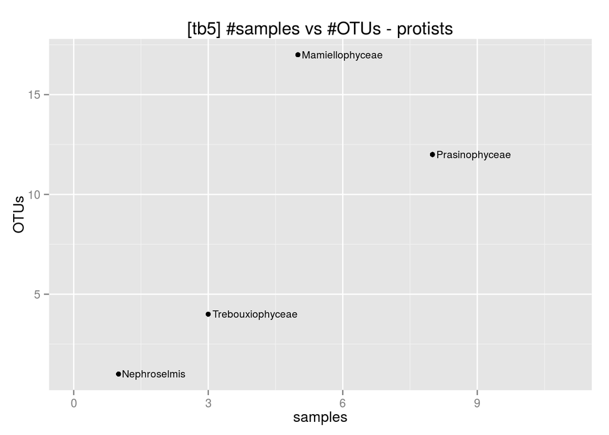

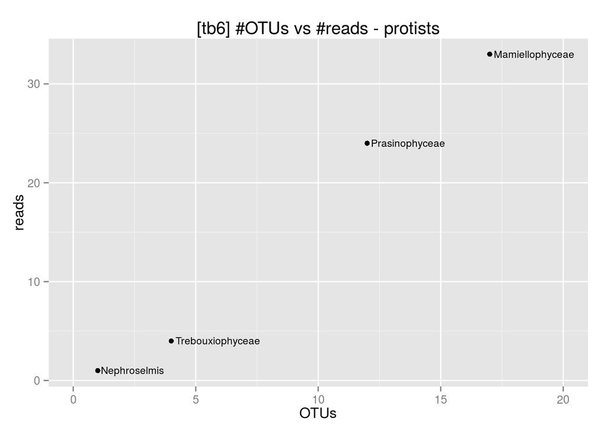

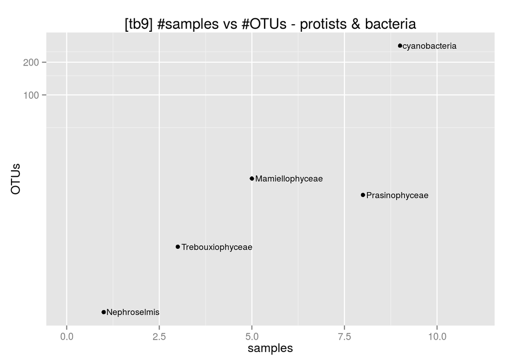

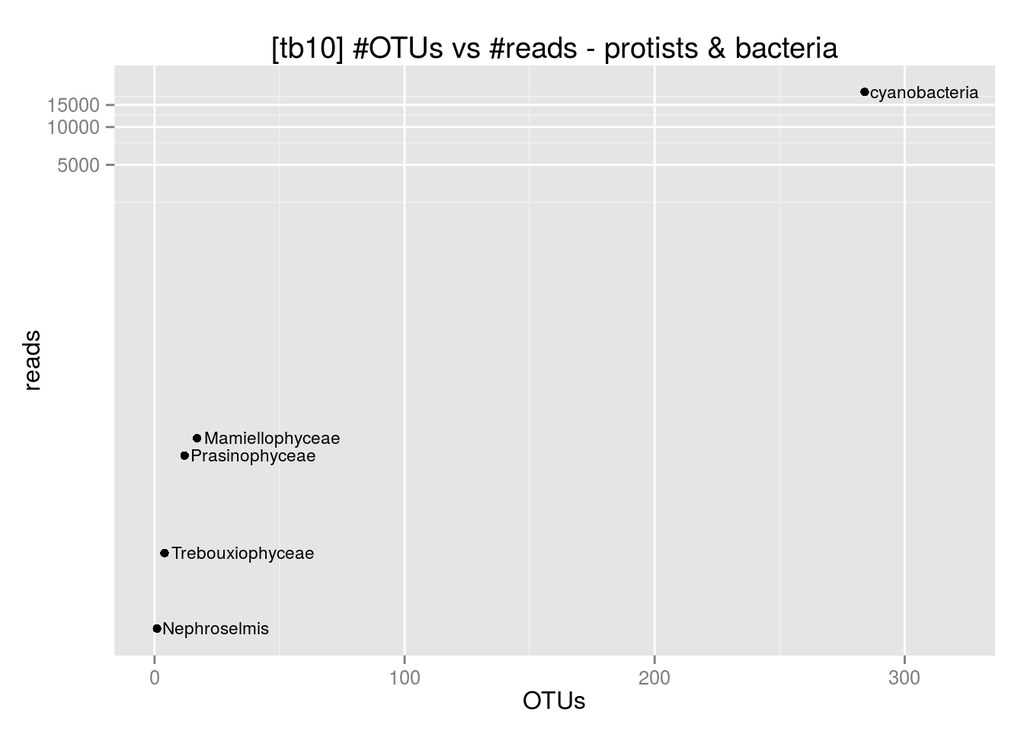